# Methods section of meta-venom

Agneesh Barua and Alexander Mikheyev

23/07/2020

# Load libraries

```r
library(kableExtra)
library(tidyverse)
library(edgeR)
library(WGCNA)
library(DESeq2)
```

# Sample data

## `Supplementary Table M 1: Taiwan habu specimens`

| library | individual | day | sex | svl | mass | mix | tissue |
| --- | --- | --- | --- | --- | --- | --- | --- |
| Pm_1_heart | Pm_1 | 1 | F | 77.5 | 107.5 | 1 | heart |
| Pm_10_heart | Pm_10 | 2 | F | 63.4 | 82.2 | 1 | heart |
| Pm_3_heart | Pm_3 | 1 | M | 62.8 | 65.5 | 2 | heart |
| Pm_5_heart | Pm_5 | 1 | M | 76.5 | 136.9 | 1 | heart |
| Pm_8_heart | Pm_8 | 2 | M | 69.0 | 89.0 | 2 | heart |
| Pm_1_kidney | Pm_1 | 1 | F | 77.5 | 107.5 | 2 | kidney |
| Pm_10_kidney | Pm_10 | 2 | F | 63.4 | 82.2 | 2 | kidney |
| Pm_3_kidney | Pm_3 | 1 | M | 62.8 | 65.5 | 1 | kidney |
| Pm_5_kidney | Pm_5 | 1 | M | 76.5 | 136.9 | 2 | kidney |
| Pm_8_kidney | Pm_8 | 2 | M | 69.0 | 89.0 | 1 | kidney |
| Pm_1_liver | Pm_1 | 1 | F | 77.5 | 107.5 | 1 | liver |
| Pm_10_liver | Pm_10 | 2 | F | 63.4 | 82.2 | 1 | liver |
| Pm_3_liver | Pm_3 | 1 | M | 62.8 | 65.5 | 2 | liver |
| Pm_5_liver | Pm_5 | 1 | M | 76.5 | 136.9 | 1 | liver |
| Pm_8_liver | Pm_8 | 2 | M | 69.0 | 89.0 | 2 | liver |
| Pm_1 | Pm_1 | 1 | F | 77.5 | 107.5 | 1 | venom gland |
| Pm_10 | Pm_10 | 2 | F | 63.4 | 82.2 | 2 | venom gland |
| Pm_11 | Pm_11 | 2 | F | 76.0 | 122.1 | 1 | venom gland |
| Pm_12 | Pm_12 | 2 | M | 98.8 | 261.2 | 2 | venom gland |
| Pm_13 | Pm_13 | 2 | F | 61.5 | 54.6 | 2 | venom gland |
| Pm_14 | Pm_14 | 4 | M | 56.3 | 44.5 | 1 | venom gland |
| Pm_15 | Pm_15 | 4 | F | 69.5 | 86.7 | 2 | venom gland |
| Pm_16 | Pm_16 | 4 | M | 79.3 | 119.4 | 1 | venom gland |
| Pm_17 | Pm_17 | 4 | F | 68.7 | 73.9 | 2 | venom gland |
| Pm_18 | Pm_18 | 4 | M | 61.8 | 64.3 | 1 | venom gland |
| Pm_19 | Pm_19 | 4 | F | 74.0 | 91.6 | 1 | venom gland |
| Pm_2 | Pm_2 | 1 | M | 62.2 | 64.4 | 2 | venom gland |
| Pm_20 | Pm_20 | 4 | F | 79.9 | 128.9 | 2 | venom gland |
| Pm_21 | Pm_21 | 4 | F | 71.3 | 109.4 | 1 | venom gland |
| Pm_22 | Pm_22 | 8 | F | 68.2 | 79.9 | 2 | venom gland |
| Pm_23 | Pm_23 | 8 | F | 58.1 | 55.0 | 1 | venom gland |
| Pm_24 | Pm_24 | 8 | F | 69.0 | 101.9 | 1 | venom gland |
| Pm_25 | Pm_25 | 8 | M | 63.1 | 74.4 | 2 | venom gland |
| Pm_26 | Pm_26 | 8 | F | 65.4 | 74.1 | 1 | venom gland |
| Pm_27 | Pm_27 | 8 | F | 73.7 | 119.1 | 2 | venom gland |
| Pm_28 | Pm_28 | 8 | M | 69.6 | 88.0 | 2 | venom gland |
| Pm_29 | Pm_29 | 8 | M | 65.3 | 71.8 | 1 | venom gland |
| Pm_3 | Pm_3 | 1 | M | 62.8 | 65.5 | 2 | venom gland |
| Pm_30 | Pm_30 | 2 | F | 70.0 | 96.6 | 2 | venom gland |
| Pm_4 | Pm_4 | 1 | F | 77.0 | 97.6 | 1 | venom gland |
| Pm_5 | Pm_5 | 1 | M | 76.5 | 136.9 | 2 | venom gland |
| Pm_6 | Pm_6 | 1 | F | 78.7 | 149.5 | 1 | venom gland |
| Pm_7 | Pm_7 | 2 | F | 68.1 | 87.0 | 1 | venom gland |
| Pm_8 | Pm_8 | 2 | M | 69.0 | 89.0 | 1 | venom gland |
| Pm_9 | Pm_9 | 2 | F | 109.3 | 295.6 | 2 | venom gland |

## Quality control

ERCC92 was added to the RNA-seq libraries for quality checking

```r
fmt <- function() function(x) as.character(round(x,2))
rsem <- read_csv("./Data_sets/rsem.csv.gz",col_types = "ccnncnccc")
ercc <- read.csv("./Data_sets/ercc.csv.gz")
```

## `Supplementary Figure M 1: Spike in tpm`

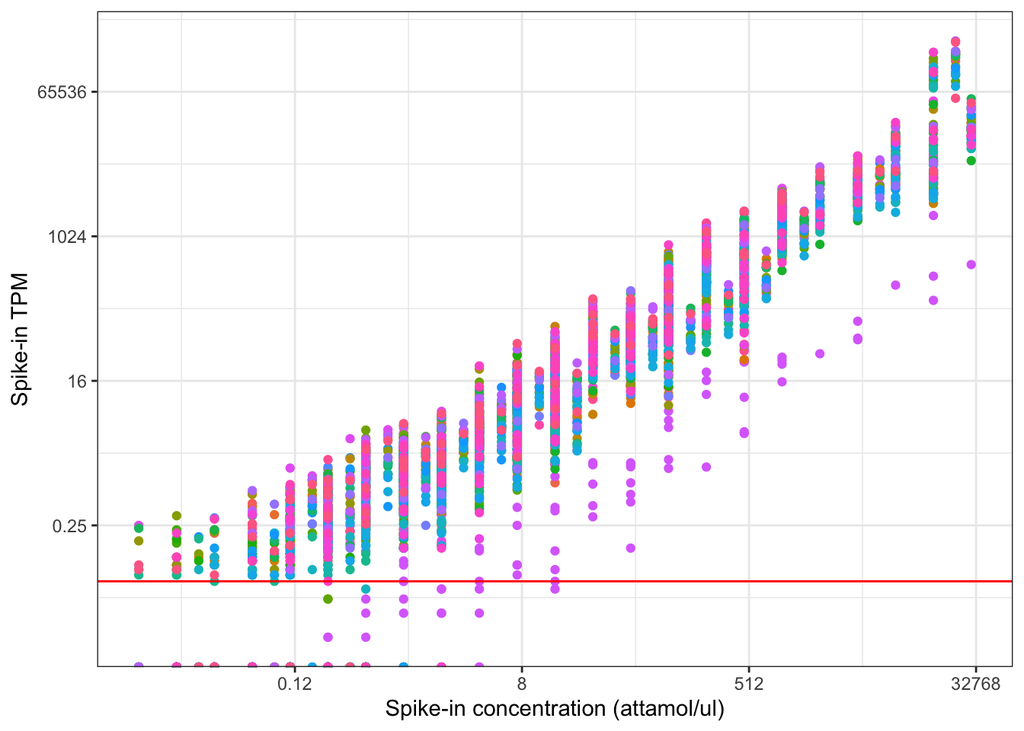

```r
ggplot(ercc, aes(conc, tpm, color=library, group=library))+geom_point()+scale_x_continuous(labels = fmt(),trans="log2")+ scale_y_continuous(labels = fmt(),trans="log2")+theme_bw()+ xlab("Spike-in concentration (attamol/ul)")+ylab("Spike-in TPM") + geom_hline(yintercept = .05, color = "red")+guides(color=F)
```

There is generally good log-linear response between observed and expected values, though we can't detect anything lower than 0.05 TPM. Looks like one library got less spike in than the rest.

```r
factors <- read_csv("./Data_sets/factors.csv", col_types = cols()) %>% filter(tissue == "venom gland")
rsemVenom <- rsem[grepl('Pm_\\d+$', rsem$library),]
# remove low expressed loci
keep <- rsemVenom %>% group_by(gene) %>% summarize(tpm = mean(tpm)) %>% filter(tpm>0.05) %>% select(gene) # genes to keep
```

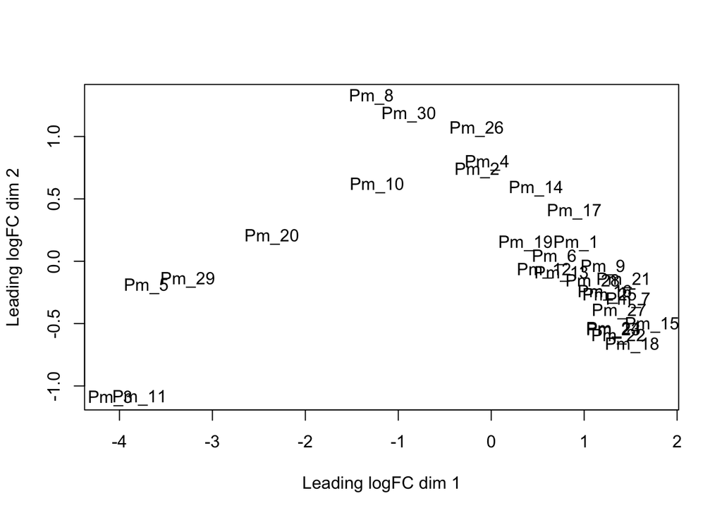

```r
tpmVenom <- rsemVenom %>% select(library, gene, count, description, class) %>% filter(gene %in% keep$gene) %>%  spread(key = library, value = count)  %>%  remove_rownames %>% column_to_rownames("gene")
# do differential gene expression on venom components only
countsVenom <- rsemVenom %>% filter(!is.na(class)) %>% select(library, gene, count) %>%  spread(key = library, value = count) %>%
  remove_rownames %>% column_to_rownames("gene")
#design matrix
design <- model.matrix(~factor(day)+factor(sex)+0, factors)
rownames(design) <- rownames(factors)
dge <- DGEList(countsVenom)
dge <- calcNormFactors(dge)
dat <- estimateGLMCommonDisp(dge, design)
dat <- estimateGLMTrendedDisp(dat, design)
dat <- estimateGLMTagwiseDisp(dat, design)
fit <- glmFit(dat,design)
mds <- plotMDS(dge)
```

```r
mdsPlot <- data.frame(mds1=mds$cmdscale.out[,1], mds2=mds$cmdscale.out[,2], ID=rownames(mds$cmdscale.out),days=factors$day,sex=factors$sex,mass=factors$mass)
```

## `Supplementary Figure M 2: MDS mass and sex`

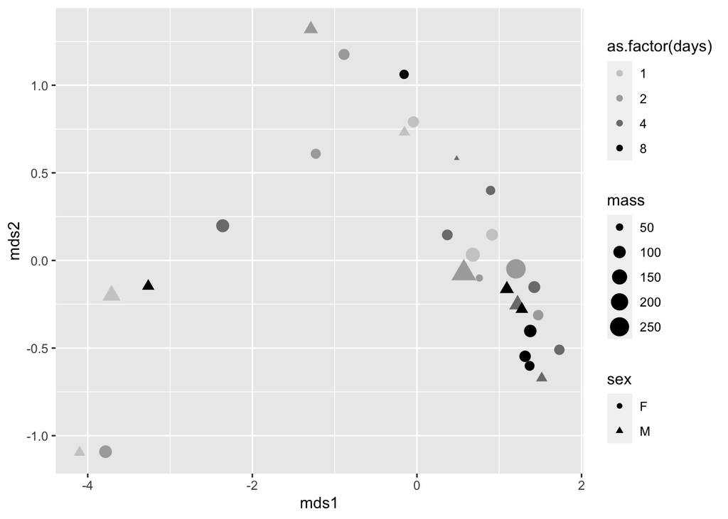

```r
ggplot(mdsPlot,aes(mds1,mds2,size=mass,shape=sex,color=as.factor(days)))+geom_point()+scale_colour_grey(start=0.8, end = 0)
```

```r
maleVsfemale <- glmLRT(fit,coef=5)
summary(caste.de <- decideTestsDGE(maleVsfemale, p=0.05, adjust="BH"))
```

```
##        factor(sex)M
## Down              0
## NotSig           76
## Up                0
```

## `Supplementary Figure M 3: Differences in venom expression between sexes is not significant`

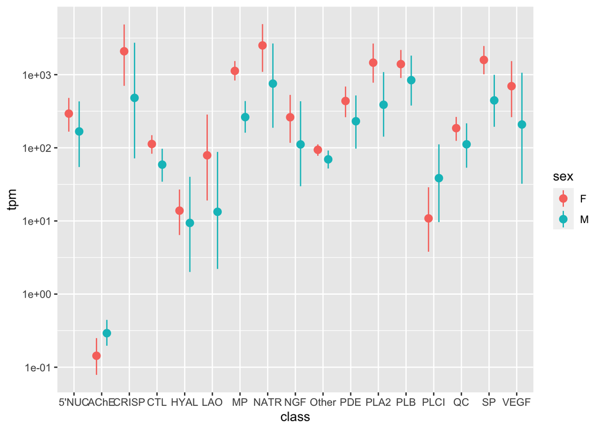

```r
ggplot(na.omit(subset(rsem, tissue == "venom gland")), aes(class,tpm, group=sex)) + scale_y_log10()+ stat_summary(fun.data = "mean_cl_boot", position = position_dodge(width = .75), aes(colour = sex))
```

```r
t.test(mass~sex,factors)
```

```
##
##  Welch Two Sample t-test
##
## data:  mass by sex
## t = 0.36085, df = 18.552, p-value = 0.7223
## alternative hypothesis: true difference in means is not equal to 0
## 95 percent confidence interval:
##  -37.66358  53.32483
## sample estimates:
## mean in group F mean in group M
##       105.95789        98.12727
```

```r
t.test(svl~sex,factors)
```

```
##
##  Welch Two Sample t-test
##
## data:  svl by sex
## t = 0.71199, df = 19.303, p-value = 0.485
## alternative hypothesis: true difference in means is not equal to 0
## 95 percent confidence interval:
##  -5.957906 12.111016
## sample estimates:
## mean in group F mean in group M
##        72.59474        69.51818
```

## Calculating soft-threshold

The lowest power to attain scale-free topology was 13 (R.sq = 0.903). Thereofre, we'll use a soft threshold of 13 to construct our network.

```r
datExpr <- t(rlog(as.matrix(round(tpmVenom %>% select(-c(Pm_7, description,class))))))
powers = c(seq(from = 10, to=16, by=1))

#call network topology analyis function
sft <- pickSoftThreshold(datExpr, powerVector = powers, verbose = 5, networkType = "signed")
```

```
## pickSoftThreshold: will use block size 2443.
##  pickSoftThreshold: calculating connectivity for given powers...
##    ..working on genes 1 through 2443 of 18313
##    ..working on genes 2444 through 4886 of 18313
##    ..working on genes 4887 through 7329 of 18313
##    ..working on genes 7330 through 9772 of 18313
##    ..working on genes 9773 through 12215 of 18313
##    ..working on genes 12216 through 14658 of 18313
##    ..working on genes 14659 through 17101 of 18313
##    ..working on genes 17102 through 18313 of 18313
##   Power SFT.R.sq slope truncated.R.sq mean.k. median.k. max.k.
## 1    10    0.865 -2.06          0.972   189.0     136.0    821
## 2    11    0.881 -2.01          0.978   143.0      97.0    727
## 3    12    0.897 -1.96          0.983   111.0      69.8    650
## 4    13    0.903 -1.92          0.981    87.3      50.9    585
## 5    14    0.911 -1.89          0.983    69.8      37.5    530
## 6    15    0.907 -1.86          0.976    56.6      27.9    483
## 7    16    0.913 -1.83          0.977    46.4      20.9    442
```

```r
sizeGrWindow(9, 5)
par(mfrow = c(1,2))
cex1 = 0.9
```

## `Supplementary Figure M 4: Soft threshold to attain scale-free topology`

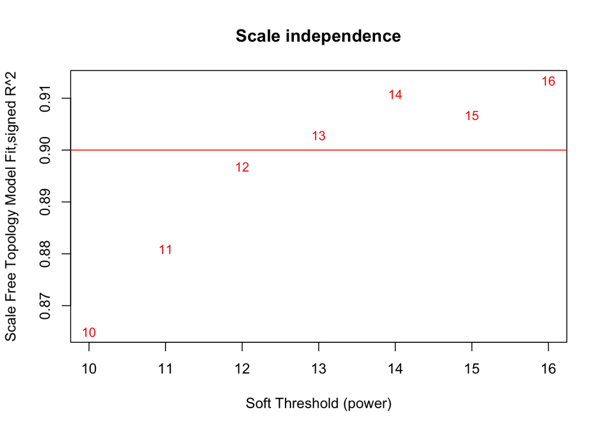

```r
# Scale-free topology fit index as a function of the soft-thresholding power
plot(sft$fitIndices[,1], -sign(sft$fitIndices[,3])*sft$fitIndices[,2],
     xlab="Soft Threshold (power)",ylab="Scale Free Topology Model Fit,signed R^2",type="n",
     main = paste("Scale independence"))
text(sft$fitIndices[,1], -sign(sft$fitIndices[,3])*sft$fitIndices[,2],
     labels=powers,cex=cex1,col="red")

# this line corresponds to using an R^2 cut-off of h
abline(h=0.90,col="red")
```

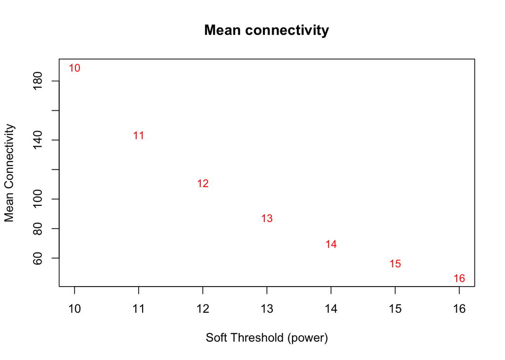

```r
plot(sft$fitIndices[,1], sft$fitIndices[,5],
     xlab="Soft Threshold (power)",ylab="Mean Connectivity", type="n",
     main = paste("Mean connectivity"))
text(sft$fitIndices[,1], sft$fitIndices[,5], labels=powers, cex=cex1,col="red")
```

# Public RNA data

## `Supplementary Table M 2: Public RNA datasets`

```r
samples<-read.csv("./Data_sets/SRA_datasets.csv")
kable(cbind(samples)) %>%
  kable_styling() %>%
  scroll_box(width = "700px", height = "500px")
```

| Taxa | Tissue | Library | Project | Layout | Study | X |
| --- | --- | --- | --- | --- | --- | --- |
| Anole | heart | SRR579558 | PRJNA176589 | Paired | Barbosa-Morais NL et al., |  |
| Anole | heart | SRR5412152 | PRJNA381064 | Single | Marin R et al., |  |
| Anole | heart | SRR5412154 | PRJNA381064 | Single | Marin R et al., |  |
| Anole | heart | SRR5412155 | PRJNA381064 | Single | Marin R et al., |  |
| Anole | liver | SRR5412164 | PRJNA381064 | Single | Marin R et al., |  |
| Anole | liver | SRR5412166 | PRJNA381064 | Single | Marin R et al., |  |
| Anole | liver | SRR5412167 | PRJNA381064 | Single | Marin R et al., |  |
| Anole | kidney | SRR579557 | PRJNA176589 | Paired | Barbosa-Morais NL et al., |  |
| Anole | kidney | SRR5412157 | PRJNA381064 | Single | Marin R et al., |  |
| Anole | kidney | SRR5412158 | PRJNA381064 | Single | Marin R et al., |  |
| Anole | kidney | SRR5412161 | PRJNA381064 | Single | Marin R et al., |  |
| Canis | heart | SRR8996963 | PRJNA396033 | Paired | https://www.broadinstitute.org/mammals-models/broad-institute-canine-genomic-resources |  |
| Canis | heart | SRR6206901 | PRJNA396033 | Paired | https://www.broadinstitute.org/mammals-models/broad-institute-canine-genomic-resources |  |
| Canis | heart | SRR8996973 | PRJNA396033 | Paired | https://www.broadinstitute.org/mammals-models/broad-institute-canine-genomic-resources |  |
| Canis | liver | SRR8997009 | PRJNA396033 | Paired | https://www.broadinstitute.org/mammals-models/broad-institute-canine-genomic-resources |  |
| Canis | liver | SRR8997042 | PRJNA396033 | Paired | https://www.broadinstitute.org/mammals-models/broad-institute-canine-genomic-resources |  |
| Canis | liver | SRR6206911 | PRJNA415552 | Paired | Chen J et al. |  |
| Canis | kidney | SRR8996953 | PRJNA396033 | Paired | https://www.broadinstitute.org/mammals-models/broad-institute-canine-genomic-resources |  |
| Canis | kidney | SRR8997002 | PRJNA396033 | Paired | https://www.broadinstitute.org/mammals-models/broad-institute-canine-genomic-resources |  |
| Canis | kidney | SRR6206906 | PRJNA396033 | Paired | https://www.broadinstitute.org/mammals-models/broad-institute-canine-genomic-resources |  |
| Canis | salivary gland | SRR5889344 | PRJNA396033 | Paired | https://www.broadinstitute.org/mammals-models/broad-institute-canine-genomic-resources |  |
| Canis | salivary gland | SRR8997053 | PRJNA396033 | Paired | https://www.broadinstitute.org/mammals-models/broad-institute-canine-genomic-resources |  |
| Gal | heart | SRR579554 | PRJNA176589 | Paired | Barbosa-Morais NL et al., |  |
| Gal | heart | SRR5412246 | PRJNA381064 | Single | Marin R et al., |  |
| Gal | heart | SRR5412248 | PRJNA381064 | Single | Marin R et al., |  |
| Gal | liver | SRR579552 | PRJNA176589 | Paired | Barbosa-Morais NL et al., |  |
| Gal | liver | SRR5412254 | PRJNA381064 | Single | Marin R et al., |  |
| Gal | liver | SRR5412256 | PRJNA381064 | Single | Marin R et al., |  |
| Gal | kidney | SRR5412256 | PRJNA381064 | Single | Marin R et al., |  |
| Gal | kidney | SRR5412250 | PRJNA381064 | Single | Marin R et al., |  |
| Gal | kidney | SRR5412251 | PRJNA381064 | Single | Marin R et al., |  |
| Homo | heart | SRR306847 | PRJNA143627 | Single | Brawand D et al., |  |
| Homo | heart | SRR306848 | PRJNA143627 | Single | Brawand D et al., |  |
| Homo | heart | SRR306849 | PRJNA143627 | Single | Brawand D et al., |  |
| Homo | liver | SRR306856 | PRJNA143627 | Single | Brawand D et al., |  |
| Homo | liver | SRR5412182 | PRJNA381064 | Single | Marin R et al., |  |
| Homo | liver | SRR5412183 | PRJNA381064 | Single | Marin R et al., |  |
| Homo | kidney | SRR306851 | PRJNA143627 | Single | Brawand D et al., |  |
| Homo | kidney | SRR306852 | PRJNA143627 | Single | Brawand D et al., |  |
| Homo | kidney | SRR5412179 | PRJNA381064 | Single | Marin R et al., |  |
| Homo | salivary gland | SRR10246417 | PRJNA576455 | Paired | Alame M et al. |  |
| Homo | salivary gland | SRR10246418 | PRJNA576455 | Paired | Alame M et al. |  |
| Mus | heart | SRR453173 | SRP012040 | Paired | GSE36025: Long RNA-seq from ENCODE/Cold Spring Harbor Lab |  |
| Mus | heart | SRR453174 | SRP012040 | Paired | GSE36025: Long RNA-seq from ENCODE/Cold Spring Harbor Lab |  |
| Mus | heart | SRR453175 | SRP012040 | Paired | GSE36025: Long RNA-seq from ENCODE/Cold Spring Harbor Lab |  |
| Mus | liver | SRR453152 | SRP012040 | Paired | GSE36025: Long RNA-seq from ENCODE/Cold Spring Harbor Lab |  |
| Mus | liver | SRR453153 | SRP012040 | Paired | GSE36025: Long RNA-seq from ENCODE/Cold Spring Harbor Lab |  |
| Mus | liver | SRR453154 | SRP012040 | Paired | GSE36025: Long RNA-seq from ENCODE/Cold Spring Harbor Lab |  |
| Mus | liver | SRR453155 | SRP012040 | Paired | GSE36025: Long RNA-seq from ENCODE/Cold Spring Harbor Lab |  |
| Mus | kidney | SRR453147 | SRP012040 | Paired | GSE36025: Long RNA-seq from ENCODE/Cold Spring Harbor Lab |  |
| Mus | kidney | SRR453148 | SRP012040 | Paired | GSE36025: Long RNA-seq from ENCODE/Cold Spring Harbor Lab |  |
| Mus | kidney | SRR453149 | SRP012040 | Paired | GSE36025: Long RNA-seq from ENCODE/Cold Spring Harbor Lab |  |
| Mus | salivary gland | SRR8133129 | PRJNA501787 | Paired | https://www.ncbi.nlm.nih.gov/geo/query/acc.cgi?acc=GSE121954 | [https://www.ncbi.nlm.nih.gov/sra/SRX4954232[accn]](https://www.ncbi.nlm.nih.gov/sra/SRX4954232%5Baccn%5D) |
| Mus | salivary gland | SRR8133134 | PRJNA501787 | Paired | https://www.ncbi.nlm.nih.gov/geo/query/acc.cgi?acc=GSE121954 | [https://www.ncbi.nlm.nih.gov/sra/SRX4954232[accn]](https://www.ncbi.nlm.nih.gov/sra/SRX4954232%5Baccn%5D) |
| Mus | salivary gland | SRR8133136 | PRJNA501787 | Paired | https://www.ncbi.nlm.nih.gov/geo/query/acc.cgi?acc=GSE121954 | [https://www.ncbi.nlm.nih.gov/sra/SRX4954232[accn]](https://www.ncbi.nlm.nih.gov/sra/SRX4954232%5Baccn%5D) |
| Mus | salivary gland | SRR8133137 | PRJNA501787 | Paired | https://www.ncbi.nlm.nih.gov/geo/query/acc.cgi?acc=GSE121954 | [https://www.ncbi.nlm.nih.gov/sra/SRX4954232[accn]](https://www.ncbi.nlm.nih.gov/sra/SRX4954232%5Baccn%5D) |
| Naja | liver | SRR8754967 | PRJNA527614 | Single | Suryamohan K |  |
| Naja | liver | SRR8754989 | PRJNA527614 | Single | Suryamohan K |  |
| Naja | kidney | SRR8754966 | PRJNA527614 | Single | Suryamohan K |  |
| Naja | kidney | SRR8754970 | PRJNA527614 | Single | Suryamohan K |  |
| Naja | salivary gland | SRR8754972 | PRJNA527614 | Single | Suryamohan K |  |
| Naja | venom gland | SRR8754964 | PRJNA527614 | Single | Suryamohan K |  |
| Naja | venom gland | SRR8754977 | PRJNA527614 | Single | Suryamohan K |  |
| Naja | venom gland | SRR8754980 | PRJNA527614 | Single | Suryamohan K |  |
| Naja | venom gland | SRR8754981 | PRJNA527614 | Single | Suryamohan K |  |
| Naja | venom gland | SRR8754986 | PRJNA527614 | Single | Suryamohan K |  |
| Naja | venom gland | SRR8754988 | PRJNA527614 | Single | Suryamohan K |  |
| Pan | heart | SRR306819 | PRJNA143627 | Single | Brawand D et al., |  |
| Pan | heart | SRR306820 | PRJNA143627 | Single | Brawand D et al., |  |
| Pan | liver | SRR306823 | PRJNA143627 | Single | Brawand D et al., |  |
| Pan | kidney | SRR306821 | PRJNA143627 | Single | Brawand D et al., |  |
| Pan | kidney | SRR306822 | PRJNA143627 | Single | Brawand D et al., |  |
| Xeno | heart | SRR579562 | PRJNA176589 | Paired | Barbosa-Morais NL et al., |  |
| Xeno | heart | SRR5412268 | PRJNA381064 | Single | Marin R et al., |  |
| Xeno | liver | SRR579561 | PRJNA176589 | Paired | Barbosa-Morais NL et al., |  |
| Xeno | liver | SRR5412274 | PRJNA381064 | Single | Marin R et al., |  |
| Xeno | liver | SRR5412276 | PRJNA381064 | Single | Marin R et al., |  |
| Xeno | kidney | SRR579562 | PRJNA176589 | Paired | Barbosa-Morais NL et al., |  |
| Xeno | kidney | SRR5412270 | PRJNA381064 | Single | Marin R et al., |  |
| Xeno | kidney | SRR5412271 | PRJNA381064 | Single | Marin R et al., |  |

# CAFE error model and output

## `Supplementary Table M 3: CAFE error model`

```bash
cat ./CAFE/res/Base_error_model.txt
```

```
maxcnt: 1
cntdiff: -1 0 1
0 0 0.831338 0.168662
1 0.168662 0.662677 0.168662
```

Two lambda CAFE output (lambda1 and lambda2)

```bash
cat ./CAFE/res/two_lambdamodel_results.txt
```

```
Model Base Result: 6909.73
Lambda: 0.0017969444427155, 0.0064501608736268
Epsilon: 0.168662
```

## `Supplementary Figure M 5: Null distribution of likelihood rations obtained from simulation in CAFE`

Once the log-likelihoods were obtained, lhtest.R script (provided by CAFE) was used to create histogram with a null distribution obtained from simulations. Significance is determined by how far left the observed likelihood ratio (2 x lnLglobal - lnLmulti) would fall on the tail of the distribution. In our case the likelihood ratio count would fall on the far left of the distribution indicating a very low p value

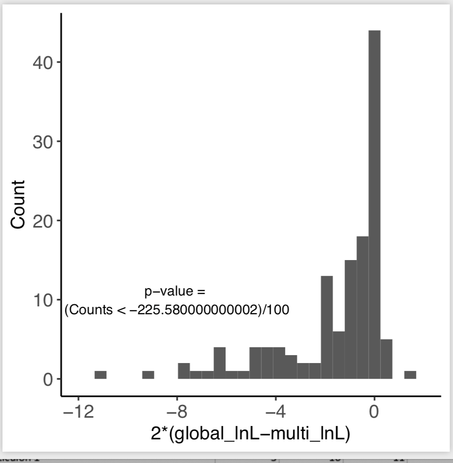